# Car Mileage Prediction

December 19, 2016

## Summary

This Shiny application is intended to demonstrate the performance of 3 popular machine learning in predicting the car mileage. The data set used for this application is the `mtcars` data which comes preloaded with base R. The application is hosted on the Shiny server and the demo can be tried out by clicking [here](https://svaditya.shinyapps.io/CarMileagePrediction/).

The objective of this application is to showcase how the capabilities of Shiny can be utilized to understand the performance of models interactively. Hope you will enjoy my application!

## Quick look at the dataset

- For the uninitiated, below is a quick look at the data.

```
##                    mpg cyl disp  hp drat    wt  qsec vs am gear carb
## Mazda RX4         21.0   6  160 110 3.90 2.620 16.46  0  1    4    4
## Mazda RX4 Wag     21.0   6  160 110 3.90 2.875 17.02  0  1    4    4
## Datsun 710        22.8   4  108  93 3.85 2.320 18.61  1  1    4    1
## Hornet 4 Drive    21.4   6  258 110 3.08 3.215 19.44  1  0    3    1
## Hornet Sportabout 18.7   8  360 175 3.15 3.440 17.02  0  0    3    2
## Valiant           18.1   6  225 105 2.76 3.460 20.22  1  0    3    1
```

- We will predict `mpg` using the other features in the data set. The application allows the users to select multiple features to build prediction models. The trained models are then used to predict `mpg`
- Along the way, the users will be able to see the total **Variance Explained** for each of the models. This helps to understand the fact that as the number of features increases the predicted values get closer to the actual value

## Models Vs RMSE

We have used the 3 most popular models for this application. They are Linear, Decision Tree and Random Forest. The graph below demonstrates model wise RMSE (Root Mean Square Error) when all the features are used to build the model and predict the `mpg` value

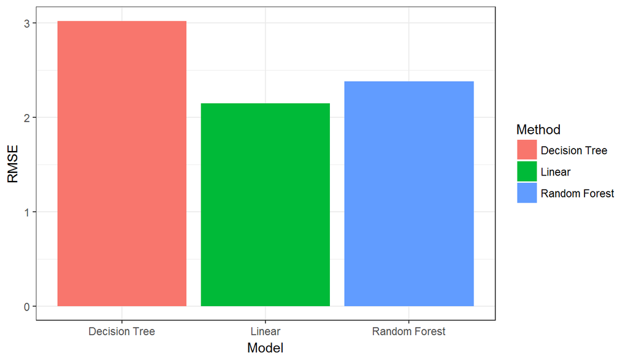

## Thank you

Finally, please consider that the intent is not to prove that one algorithm performs better than the other. With sufficient tuning of respective parameters, the performance of the algorithms can be made comparable to each other.